# Philosophy of Logic and Language

Jonny McIntosh

1. Frege's Conception of Logic

# OVERVIEW

These lectures cover material for paper 108, *Philosophy of Logic and Language*.

They will focus on issues in philosophy of logic and language as they arise in the work of Frege and Tarski.

A tentative schedule:

1. Frege's Conception of Logic
2. Frege's Logical Innovation
3. Sense and Reference
4. Frege on Truth
5. Tarski on Truth
6. Kripke on Truth
7. The Liar Paradox
8. Logical Consequence

# FREGE

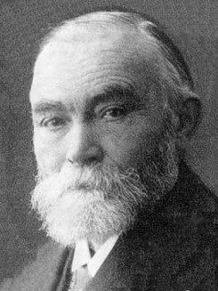

Gottlob Frege (1848-1925)

Frege's work up until 1902 was guided by his **LOGICISM**, the view that the truths of arithmetic can be deduced from the laws of logic alone.

In pursuit of this aim, Frege developed what is essentially (second-order) predicate logic ...

... and, with his masterpiece, *The Foundations of Arithmetic* (1884), provided one of the founding texts of analytic philosophy.

But the attempt ended in failure. As Bertrand Russell pointed out to him in 1902, Frege's system contained a contradiction.

- We won't look at Frege's logicism in detail.
- Instead: the underlying conception of logic.

# FREGE v. KANT

Frege's target is Kant, who held that the truths of arithmetic *cannot* be deduced from the laws of logic alone.

Kant (himself reacting to Hume) drew distinctions between:

- analytic and synthetic judgements, and
- *a priori* and *a posteriori* knowledge or cognitions.

The analytic-synthetic distinction concerns the content of a judgement:

"In all judgements in which the relation of a subject to the predicate is thought [...] this relation is possible in two different ways. Either the predicate B belongs to the subject A as something that is (covertly) contained in this concept A; or B lies entirely outside the concept A, though to be sure it stands in connection with it. In the first case I call the judgement **analytic**, in the second **synthetic**." (Kant *CPR*, A7/B11.)

The *a priori*-*a posteriori* distinction concerns the grounds of a judgement:

"We shall understand by *a priori* cognitions not those that occur independently of this or that experience, but rather those that occur *absolutely* independent of all experience. Opposed to them are empirical cognitions, or those that are possible only *a posteriori*, i.e. through experience." (Kant *CPR*, B3.)

Analytic and *a posteriori*?

N/A.

Analytic and *a priori*?

The judgement that all red apples are apples.

Synthetic and *a posteriori*?

The judgement that this apple is red.

Synthetic and *a priori*?

Kant: geometric and arithmetical judgements.

- Frege: Kant is right about geometry, but not arithmetic.
- Arithmetic, according to Frege, is analytic, not synthetic.

# A WORRY

Frege's conception of the analytic-synthetic distinction (and also of the *a priori-a posteriori* distinction) is quite different to Kant's.

Whereas Kant's distinction concerns the *content* of a judgement, Frege's concerns its *justification* — by which he means something like its ideal proof:

"The problem becomes, in fact, that of finding the proof of the proposition, and of following it up right back to the primitive truths. If, in carrying out this process, we come only on general logical laws and on definitions, then the truth is an analytic one, bearing in mind that we must take account also of all propositions upon which the admissibility of any of the definitions depends. If, however, it is impossible to give the proof without making use of truths which are not of a general logical nature, but belong to the sphere of some special science, then the proposition is a synthetic one." (Frege *Foundations*, §3.)

Frege's *logic* differs from Kant's as well. We'll look at this in more detail next week, but, put briefly, logic encompasses much more for Frege than for Kant.

This raises a worry.

Consider Poincaré on Russell's logicism:

"We see how much richer the new logic is than the classical logic; the symbols are multiplied and allow of varied combinations which are no longer limited in number. Has one the right to give this extension to the meaning of the word *logic*? It would be useless to examine this question and to seek with Russell a mere quarrel about words. Grant him what he demands, but be not astonished if certain verities declared irreducible to logic in the old sense of the word find themselves now reducible to logic in the new sense — something very different." (Poincaré 1908, p. 461; quoted in Macfarlane 2002, p. 27)

Similarly, even if Frege had managed to show that arithmetic can be deduced from what he calls logic, why couldn't Kant take this to show that Frege's "logic" isn't *genuine* logic?

To see how Frege might respond, consider what Mark Textor calls Frege's *argument from similarity* (Textor 2011, p. 18), designed to motivate Frege's logicism:

"For purposes of conceptual thought we can always assume the contrary of some one or other of the geometrical axioms, without involving ourselves in any self-contradictions when we draw deductive consequences from the assumptions that conflict with intuition. This possibility shows that the axioms of geometry are independent of one another and of the basic laws of logic, and are therefore synthetic.

"Can the same be said of the fundamental principles of the science of numbers? Does not everything collapse into confusion when we try denying them? Would thinking itself still be possible? Does not the ground of arithmetic lie deeper than that of all empirical knowledge, deeper than even that of geometry?

"The truths of arithmetic govern the domain of the countable. This is the most comprehensive of all; not only of what is actual, not only what is intuitable, but everything thinkable. Should not the laws of number then stand in the most intimate connection with the laws of thought?" (Frege *Foundations* §14; Mark Textor's translation.)

Frege is arguing that arithmetic is similar to logic (the laws of thought) in two key respects. Both are in some sense:

- maximally general
- undeniable

Rightly understood, this is a conception of logic that Kant arguably shared (Macfarlane 2002). If so, it provides common ground on which Frege can argue for his logicism.

But how exactly is this conception of logic rightly understood? In what sense does Frege think that logic is maximally general and undeniable?

# LOGIC for FREGE

# LAWS OF THOUGHT

To better understand Frege's conception of logic, it helps to first understand what he means when he calls the principles of logic *the laws of thought*.

First, notice that the word 'thought' is ambiguous.

It can refer either to a certain kind of activity or *act*, thinking, or to the *object* of that act, that which is thought.

This is known as an **ACT-OBJECT** ambiguity. (Compare 'utterance', 'experience'.)

Frege holds that the principles of logic are laws governing certain *acts* of thought (or better, reasoning): judgings and inferrings.

Now, as Frege has it, the principles of logic include principles like Basic Law **IIa**:

- ∀F∀x (∀y F(y) → F(x)) (*Basic Laws* 1, §20)

In what sense can such principles be regarded as *laws* of thought or reasoning?

Frege is not claiming that principles like **IIa** describe how we in fact reason.

Rather, he is claiming they somehow determine how we *should* reason. He says:

"The ambiguity of the word 'law' is fatal here. In one sense it states what is, in the other it prescribes what should be. Only in the latter sense can the logical laws be called laws of thought, in laying down how one should think." (*Basic Laws*, p. xv)

But this is puzzling. **IIa** doesn't contain **DEONTIC** vocabulary — words like 'ought' or 'may'.

So principles like **IIa** seem to be **DESCRIPTIVE**, not **NORMATIVE**. So how can they determine how we *should* reason?

Frege's answer (roughly put): the principles of logic describe reality, and so yield prescriptions for reasoning *about* reality.

Some questions:

- Do Frege's logical principles describe reality?
- How do they yield prescriptions for reasoning about reality?

# HARMAN'S CHALLENGE

Consider the fact that some of the logical principles of Frege's system are rules of inference, like *modus ponens*:

- *P*, *P → Q* ⊢ *Q*

How do principles like *modus ponens* determine prescriptions for reasoning? One might try the following **BRIDGE PRINCIPLE**:

**LOGICAL IMPLICATION PRINCIPLE** (**IMP**): If it is a logical consequence of S's beliefs that A, S ought to believe that A.

But as Harman points out, **IMP** seems to be subject to counter-examples.

Suppose I believe that it is raining, and also believe that if it is raining then the streets are wet.

Then it is a logical consequence of my beliefs that the streets are wet.

**IMP** thus entails that I ought to believe that the streets are wet.

But suppose I see that the streets are *not* wet. The rational thing to do is to give up one of the other beliefs.

In response, the obvious options are to either somehow argue that examples like these aren't genuine counterexamples...

...or come up with alternatives to the likes of **IMP**. For further discussion, see the suggestions in the accompanying reading list.

# MAXIMAL GENERALITY

Suppose Frege is right: the principles of logic do describe reality and do thereby yield prescriptions for reasoning. In what way, then, is logic distinctive?

The problem is that the principles of sciences like (applied) geometry and physics *also* describe reality, and so in Frege's view also yield prescriptions for reasoning:

"Any law asserting what is can be conceived as prescribing that one ought to think in conformity with it, and thus is in that sense a law of thought. This holds of the laws of geometry and physics no less than for the laws of logic." (Frege *Basic Laws*, p. xv.)

What distinguishes logic, Frege thinks, is that its principles yield prescriptions for *all* reasoning:

"The [laws of logic] have a special title to the name 'laws of thought' only if we mean to assert that they are the most general laws, which prescribe universally the way in which one ought to think if one is to think at all." (*ibid*.)

Geometry (physics) only describes — and so yields prescriptions for reasoning about — things belonging to spatial (physical) reality.

Logic, by contrast, is maximally general: it describes — and so yields prescriptions for reasoning about — *all* things.

# CONSTITUTIVE NORMS

So much for maximal generality. Frege also thinks logic is in some way *undeniable*. But in what way, exactly?

Given what we've seen so far, Frege holds that, no matter what one is reasoning about, if one violates the norms determined by logical principles then one is not reasoning *correctly*.

But many think Frege has something stronger in mind (something Kant arguably also held,) namely that logic yields **CONSTITUTIVE NORMS** of thought or reasoning.

Constitutive norms governing an activity are distinguished from merely **REGULATIVE** norms:

"As a start, we might say that regulative rules regulate antecedently or independently existing forms of behaviour... constitutive rules do not merely regulate, they create or define new forms of behaviour. The rules of football or chess, for example, do not merely regulate playing football or chess but as it were they create the very possibility of playing such games." (Searle 1969 *Speech Acts*, p. 33)

In either case, if one violates the rules then one is not playing chess *correctly*. But the constitutive rules have extra bite:

If one engages in an activity in such a way that the constitutive rules of chess do not apply to it, then it cannot count as playing chess.

Similarly, perhaps: if one engages in an activity in such a way that the norms that logic yields do not apply to it, then it cannot count as reasoning.

This seems to be what Frege has in mind in talking of undeniability in the argument from similarity:

"Does not everything collapse into confusion when we try denying [the principles of arithmetic]? Would thinking itself still be possible?" (Frege *Foundations*, §14.)

And also, albeit more tentatively, in *Basic Laws*, where Frege considers (but neither disputes nor endorses) the following:

"when we judge we cannot discard this law — of identity, for example — but have to acknowledge it if we do not want to lead our thinking into confusion and in the end abandon judgement altogether." (Frege *Basic Laws*, p. xvii)

# SUMMARY

In thinking through how Frege might respond to Poincaré-style challenges, we've seen that he holds a conception of logic on which:

- Logical principles describe reality
- And so yield prescriptions for reasoning

This latter claim faces a challenge raised by Gilbert Harman: what are the bridge principles by which logical principles yield these prescriptions?

Frege also thinks logic is *maximally general*: unlike physics and geometry, it describes things that belong to *any* aspect of reality.

Lastly, he also seems to think that it is *undeniable* in the sense that the norms for reasoning that it yields are *constitutive* of reasoning.

# NEXT WEEK

Frege's logical innovations.